# Assignment05

Erik Fichter

10/3/2020

```r
library(tidycensus)
library(tidyverse)
library(jtools)
library(interactions)
library(huxtable)
```

The scope of mutating both categorical variables is to set the focus more narrow, in order to differentiate for the building type between a house, small, medium and large Apartment buildings and for the transportation mode to reduce the categories to the car, Subway, by foot and others.

```r
ma_re_trans_data<- read.csv("2018 RE Transportation.csv")%>%

  mutate(struct_type = case_when(
    BLD_label=="2 Apartments" ~ "House",
    BLD_label=="10-19 Apartments" ~ "Medium Apartment Building",
    BLD_label=="One-family house detached" ~ "House",
    BLD_label=="3-4 Apartments" ~ "Small Apartment Building",
    BLD_label=="Mobile home or trailer" ~ "Other",
    BLD_label=="50 or more apartments" ~ "Large Apartment Building",
    BLD_label=="20-49 Apartments" ~ "Large Apartment Building",
    BLD_label=="5-9 Apartments" ~ "Small Apartment Building",
    BLD_label=="One-family house attached" ~ "House",
    BLD_label=="Boat, RV, van, etc." ~ "Other")) %>%

mutate(transp_type = case_when(
    JWTR_label=="Bus or trolley bus " ~ "Car",
    JWTR_label=="Car, truck, or van" ~ "Car",
    JWTR_label=="Ferryboat" ~ "Others",
    JWTR_label=="Motorcycle" ~ "Others",
    JWTR_label=="Other method" ~ "Others",
    JWTR_label=="Railroad" ~ "Others",
    JWTR_label=="Streetcar or trolley car (carro publico in Puerto Rico)" ~ "Others",
    JWTR_label=="Subway or elevated" ~ "Subway",
    JWTR_label=="Taxicab" ~ "Car",
    JWTR_label=="Walked" ~ "ByFoot"))

ma_re_trans_data
```

## Linear Regression Model

Dependent Variable: Value of the property (continuous)

**Independent Variables:

1. Gross Monthly Rent (continuous): GRNTP
2. Amount and type of units within the structure (categorical): struct_type
3. Number of bedrooms (continuous): BDSP
4. Travel time to work (continuous): JWMNP
5. Means of transportation (categorical): transp_type

## Original Linear Regression

Below is the linear regression I ran last week. The dependent variable is the Value of the Property. The independent variables are Gross Monthly Rent, Type of Structure, Number of bedrooms, Travel time to work and Means of transportation.

I dont know why the Categories “House” and “ByFoot” dont appear.

```r
options(scipen = 999)
model1 <- lm(VALP ~ GRNTP + struct_type + BDSP + JWMNP + transp_type, data = ma_re_trans_data)

summary(model1)
```

```
##
## Call:
## lm(formula = VALP ~ GRNTP + struct_type + BDSP + JWMNP + transp_type,
##     data = ma_re_trans_data)
##
## Residuals:
##      Min       1Q   Median       3Q      Max
## -1047139  -195779   -77147    74260  4579497
##
## Coefficients: (1 not defined because of singularities)
##                                       Estimate Std. Error t value
## (Intercept)                           220159.5    23688.2   9.294
## GRNTP                                       NA         NA      NA
## struct_typeLarge Apartment Building   230094.5    22471.0  10.240
## struct_typeMedium Apartment Building   10716.8    36718.1   0.292
## struct_typeOther                     -169593.4    41628.5  -4.074
## struct_typeSmall Apartment Building   133989.7    15118.0   8.863
## BDSP                                  136512.7     3375.2  40.446
## JWMNP                                    323.7      128.8   2.513
## transp_typeCar                       -202010.2    21021.3  -9.610
## transp_typeOthers                     -82768.8    26752.1  -3.094
## transp_typeSubway                       -280.8    26677.1  -0.011
##                                                  Pr(>|t|)
## (Intercept)                          < 0.0000000000000002 ***
## GRNTP                                                  NA
## struct_typeLarge Apartment Building  < 0.0000000000000002 ***
## struct_typeMedium Apartment Building              0.77039
## struct_typeOther                                0.0000464 ***
## struct_typeSmall Apartment Building  < 0.0000000000000002 ***
## BDSP                                 < 0.0000000000000002 ***
## JWMNP                                             0.01197 *
## transp_typeCar                       < 0.0000000000000002 ***
## transp_typeOthers                                 0.00198 **
## transp_typeSubway                                 0.99160
## ---
## Signif. codes:  0 '***' 0.001 '**' 0.01 '*' 0.05 '.' 0.1 ' ' 1
##
## Residual standard error: 449400 on 22479 degrees of freedom
##   (513 observations deleted due to missingness)
## Multiple R-squared:  0.08319,    Adjusted R-squared:  0.08282
## F-statistic: 226.6 on 9 and 22479 DF,  p-value: < 0.00000000000000022
```

# Log Transformation

The difference between traveling 5 minutes to work and 10 minutes is probably more substantial than the difference between earning 60 minutes and and 65 minutes travel time. Therefore I will log-transform my traveltime variable.

```r
options(scipen = 999)
model2 <- lm(VALP ~ GRNTP + struct_type + log(JWMNP) + BDSP + transp_type, data = ma_re_trans_data)

summary(model2)
```

```
##
## Call:
## lm(formula = VALP ~ GRNTP + struct_type + log(JWMNP) + BDSP +
##     transp_type, data = ma_re_trans_data)
##
## Residuals:
##      Min       1Q   Median       3Q      Max
## -1048974  -197062   -75394    76808  4572202
##
## Coefficients: (1 not defined because of singularities)
##                                      Estimate Std. Error t value
## (Intercept)                            187413      25025   7.489
## GRNTP                                      NA         NA      NA
## struct_typeLarge Apartment Building    227709      22472  10.133
## struct_typeMedium Apartment Building    10341      36707   0.282
## struct_typeOther                      -168989      41615  -4.061
## struct_typeSmall Apartment Building    133060      15114   8.804
## log(JWMNP)                              17219       3831   4.495
## BDSP                                   136425       3374  40.435
## transp_typeCar                        -213144      21226 -10.042
## transp_typeOthers                      -96700      26859  -3.600
## transp_typeSubway                      -16350      26983  -0.606
##                                                  Pr(>|t|)
## (Intercept)                            0.0000000000000719 ***
## GRNTP                                                  NA
## struct_typeLarge Apartment Building  < 0.0000000000000002 ***
## struct_typeMedium Apartment Building             0.778167
## struct_typeOther                       0.0000490794954674 ***
## struct_typeSmall Apartment Building  < 0.0000000000000002 ***
## log(JWMNP)                             0.0000069909029905 ***
## BDSP                                 < 0.0000000000000002 ***
## transp_typeCar                       < 0.0000000000000002 ***
## transp_typeOthers                                0.000319 ***
## transp_typeSubway                                0.544582
## ---
## Signif. codes:  0 '***' 0.001 '**' 0.01 '*' 0.05 '.' 0.1 ' ' 1
##
## Residual standard error: 449200 on 22479 degrees of freedom
##   (513 observations deleted due to missingness)
## Multiple R-squared:  0.08375,    Adjusted R-squared:  0.08339
## F-statistic: 228.3 on 9 and 22479 DF,  p-value: < 0.00000000000000022
```

## Adding an interaction term

```r
options(scipen = 999)
model3 <- lm(VALP ~ GRNTP:BDSP + struct_type:BDSP + BDSP + JWMNP:BDSP + transp_type:BDSP, data = ma_re_trans_data)

summary(model3)
```

```
##
## Call:
## lm(formula = VALP ~ GRNTP:BDSP + struct_type:BDSP + BDSP + JWMNP:BDSP +
##     transp_type:BDSP, data = ma_re_trans_data)
##
## Residuals:
##      Min       1Q   Median       3Q      Max
## -1198324  -195315   -76906    76409  4372382
##
## Coefficients: (1 not defined because of singularities)
##                                            Estimate Std. Error t value
## (Intercept)                                68617.79   11236.00   6.107
## BDSP                                      175347.58    7292.74  24.044
## GRNTP:BDSP                                       NA         NA      NA
## BDSP:struct_typeLarge Apartment Building  119847.97   12091.25   9.912
## BDSP:struct_typeMedium Apartment Building     90.14   18683.61   0.005
## BDSP:struct_typeOther                     -90215.85   16823.71  -5.362
## BDSP:struct_typeSmall Apartment Building   39176.05    5648.28   6.936
## BDSP:JWMNP                                   109.18      37.73   2.894
## BDSP:transp_typeCar                       -53603.16    6644.87  -8.067
## BDSP:transp_typeOthers                    -15835.63    8206.01  -1.930
## BDSP:transp_typeSubway                      8810.99    8411.63   1.047
##                                                       Pr(>|t|)
## (Intercept)                               0.000000001032120135 ***
## BDSP                                      < 0.0000000000000002 ***
## GRNTP:BDSP                                                  NA
## BDSP:struct_typeLarge Apartment Building  < 0.0000000000000002 ***
## BDSP:struct_typeMedium Apartment Building              0.99615
## BDSP:struct_typeOther                     0.000000082922472501 ***
## BDSP:struct_typeSmall Apartment Building  0.000000000004145003 ***
## BDSP:JWMNP                                             0.00381 **
## BDSP:transp_typeCar                       0.000000000000000757 ***
## BDSP:transp_typeOthers                                 0.05365 .
## BDSP:transp_typeSubway                                 0.29489
## ---
## Signif. codes:  0 '***' 0.001 '**' 0.01 '*' 0.05 '.' 0.1 ' ' 1
##
## Residual standard error: 450000 on 22479 degrees of freedom
##   (513 observations deleted due to missingness)
## Multiple R-squared:  0.08062,    Adjusted R-squared:  0.08025
## F-statistic:   219 on 9 and 22479 DF,  p-value: < 0.00000000000000022
```

```r
options(scipen = 999)
model4 <- lm(VALP ~ GRNTP:JWMNP + struct_type:JWMNP + JWMNP + BDSP:JWMNP + transp_type:JWMNP, data = ma_re_trans_data)

summary(model4)
```

```
##
## Call:
## lm(formula = VALP ~ GRNTP:JWMNP + struct_type:JWMNP + JWMNP +
##     BDSP:JWMNP + transp_type:JWMNP, data = ma_re_trans_data)
##
## Residuals:
##      Min       1Q   Median       3Q      Max
## -1716079  -206837   -85665    76102  4487503
##
## Coefficients: (1 not defined because of singularities)
##                                            Estimate Std. Error t value
## (Intercept)                                481760.6     5088.2  94.681
## JWMNP                                       -1310.6      921.7  -1.422
## GRNTP:JWMNP                                      NA         NA      NA
## JWMNP:struct_typeLarge Apartment Building    4603.4      569.9   8.078
## JWMNP:struct_typeMedium Apartment Building    638.9      891.0   0.717
## JWMNP:struct_typeOther                      -3851.5     1260.6  -3.055
## JWMNP:struct_typeSmall Apartment Building    2696.5      392.6   6.869
## JWMNP:BDSP                                   2861.2       86.0  33.271
## JWMNP:transp_typeCar                        -8044.5      871.2  -9.234
## JWMNP:transp_typeOthers                     -7009.1      899.9  -7.789
## JWMNP:transp_typeSubway                     -5669.3      916.2  -6.188
##                                                        Pr(>|t|)
## (Intercept)                                < 0.0000000000000002 ***
## JWMNP                                                   0.15507
## GRNTP:JWMNP                                                  NA
## JWMNP:struct_typeLarge Apartment Building  0.000000000000000692 ***
## JWMNP:struct_typeMedium Apartment Building              0.47335
## JWMNP:struct_typeOther                                  0.00225 **
## JWMNP:struct_typeSmall Apartment Building  0.000000000006626810 ***
## JWMNP:BDSP                                 < 0.0000000000000002 ***
## JWMNP:transp_typeCar                       < 0.0000000000000002 ***
## JWMNP:transp_typeOthers                    0.000000000000007042 ***
## JWMNP:transp_typeSubway                    0.000000000620472728 ***
## ---
## Signif. codes:  0 '***' 0.001 '**' 0.01 '*' 0.05 '.' 0.1 ' ' 1
##
## Residual standard error: 455800 on 22479 degrees of freedom
##   (513 observations deleted due to missingness)
## Multiple R-squared:  0.05674,    Adjusted R-squared:  0.05637
## F-statistic: 150.3 on 9 and 22479 DF,  p-value: < 0.00000000000000022
```

##Visualizing model fit

It shows that the original values and the one with the log transformation as statistically more significant than the ones with an interaction.

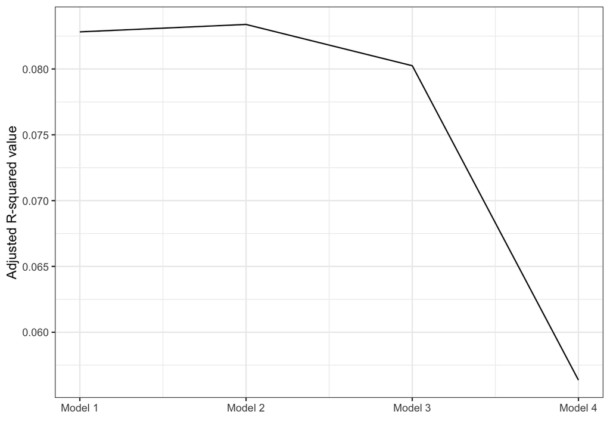

```r
ModelFit <- tibble(model = c(1, 2, 3,4),
                   R_square = c(summary(model1)$adj.r.squared,
                                summary(model2)$adj.r.squared,
                                summary(model3)$adj.r.squared,
                                summary(model4)$adj.r.squared))
ggplot(ModelFit, aes(x = model, y = R_square)) +
  geom_line() +
  scale_x_continuous(name = "",
                   breaks = breaks <- seq(1, 4, by = 1),
                   labels = paste("Model", breaks)) +
  scale_y_continuous(name = "Adjusted R-squared value") +
  theme_bw()
```